# Tree Sound Absorption

## Sonification: White Noise Through Tree Filters

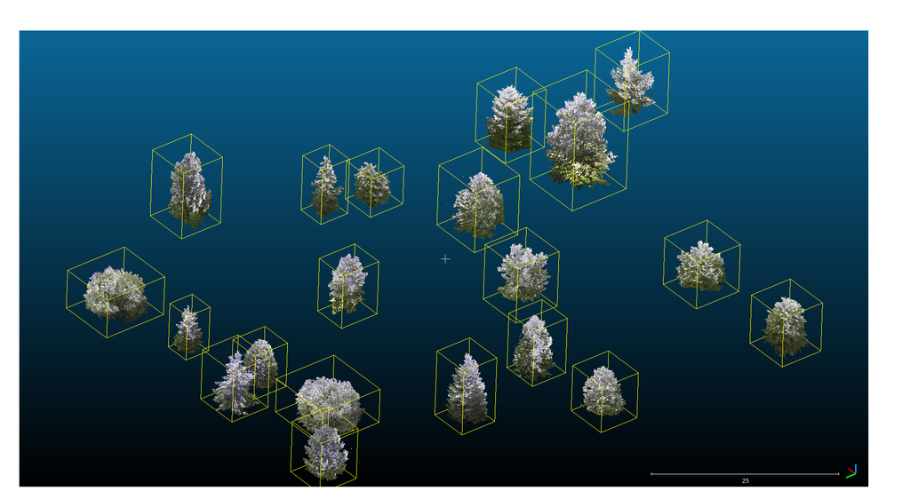

[interactive chart not shown]

## Sonification: White Noise Through Schoolyard Sounds

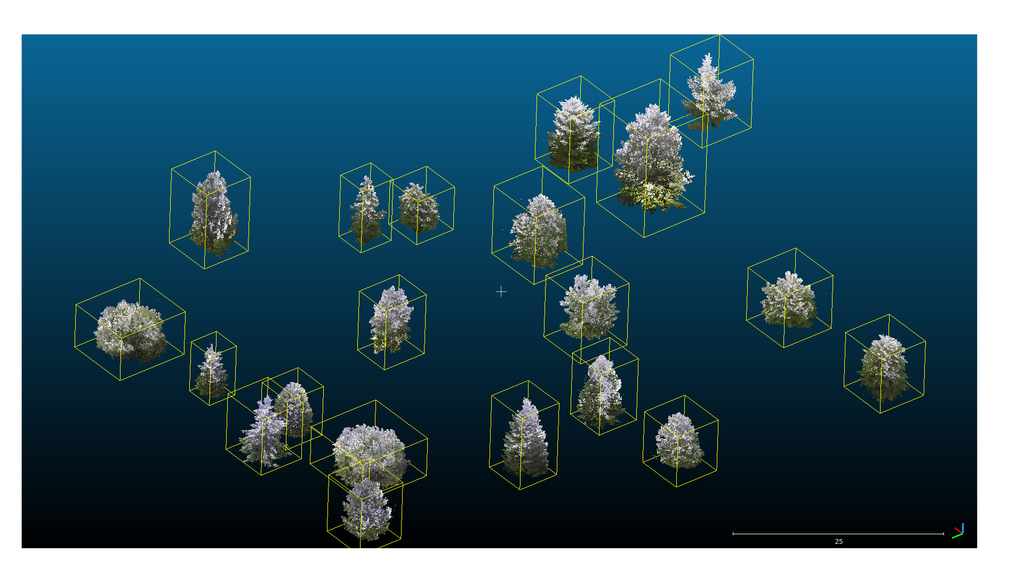

[interactive chart not shown]

(sorry for harp, could not find another sample. in principle, any sound can be used)

## Conclusions

**Broadleaf:** Structural and physiological traits explain attenuation well

**Needleleaf:** High-frequency and overall attenuation not predictable from traits — may reflect rather than absorb

**Methodological concerns:**

- Hit point sometimes located near tree center rather than crown edge
- Gap fraction assumes straight-line sound propagation
- Small sample size (n = 8–9 per group)

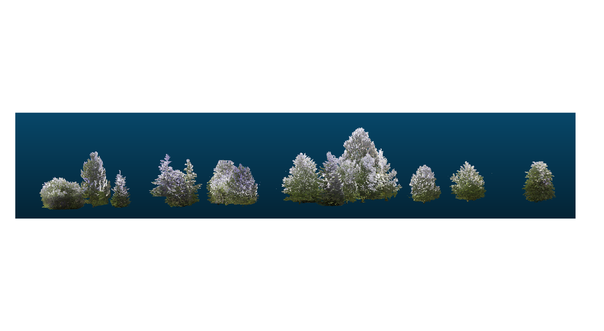